# 01_DESeq_analyze_EONVersion

Romario Romain & Erin Osborne Nishimura

1/28/2021

*NOTES: I need to update it to make a Pearson Correlation table*

# Analysis: DESeq2 analysis

The purpose of this analysis is to run the full set of RNA-seq samples through DESeq2

## Step 1: Install required libraries if not already present; Load libraries:

Install the following if not already installed:

- DESeq2
- RColorBrewer
- pheatmap
- ggplot2
- BiocManager
- GenomicFeatures
- ensembldb
- biomaRt
- dplyr
- tibble
- tidyverse
- gridExtra

Load required packages.

```r
# Do this every time.
# Load packages:
library(DESeq2)
library(RColorBrewer)
library(pheatmap)
library(ggplot2)
library(BiocManager)
library(GenomicFeatures)
library(ensembldb)
library(biomaRt)
library(dplyr)
library(tibble)
library(tidyverse)
library(gridExtra)
```

Set date:

```
## [1] "210215"
```

## Step 2: Import the datasets

Import the counts dataset:

```r
# If necessary:
#setwd("~/Dropbox/LABWORK/PROJECTS/201114_CancerProgressionAnalysis/05_DESeq/02_scripts")

# import the counts data - aligned to hg38
countsData <- read.table(file = "../01_input/20200116_counts.txt", header = TRUE, row.names = 1, skip = 2)

# import the counts data - aligned to transgenes
transgeneCountsData <- read.table(file = "../01_input/210210_transgene_counts.txt", header = TRUE, row.names = 1, skip = 1)
```

Import the metadata file:

```r
# Read in the metadata
metadata <- read.table(file = "../01_input/RR_ARPE_Deluca_Collab_manifest.txt", header = FALSE) # import the data
colnames(metadata) <- c("fasta1", "fasta2", "names", "rep","sample")
metadata
```

```
##                     fasta1                  fasta2      names rep sample
## 1     RR001_S1_L002_R1_001    RR001_S1_L002_R2_001  MekDD_1_1   1  MekDD
## 2     RR002_S2_L002_R1_001    RR002_S2_L002_R2_001 Aktmyr_1_2   1 Aktmyr
## 3     RR003_S3_L002_R1_001    RR003_S3_L002_R2_001 ARPE19_1_3   1 ARPE19
## 4     RR004_S4_L002_R1_001    RR004_S4_L002_R2_001 RasV12_1_4   1 RasV12
## 5     RR005_S5_L002_R1_001    RR005_S5_L002_R2_001  T53D4_1_5   1  T53D4
## 6    RR012_S49_L002_R1_001   RR012_S49_L002_R2_001 negclt_3_0   3 negclt
## 7    RR013_S50_L002_R1_001   RR013_S50_L002_R2_001  MekDD_3_1   3  MekDD
## 8    RR014_S51_L002_R1_001   RR014_S51_L002_R2_001 Aktmyr_3_2   3 Aktmyr
## 9    RR015_S52_L002_R1_001   RR015_S52_L002_R2_001 ARPE19_3_3   3 ARPE19
## 10   RR016_S53_L002_R1_001   RR016_S53_L002_R2_001 RasV12_3_4   3 RasV12
## 11   RR017_S54_L002_R1_001   RR017_S54_L002_R2_001  T53D4_3_5   3  T53D4
## 12 RROOO10_S10_L002_R1_001 RROOO10_S10_L002_R2_001 RasV12_2_4   2 RasV12
## 13 RROOO11_S11_L002_R1_001 RROOO11_S11_L002_R2_001  T53D4_2_5   2  T53D4
## 14   RROOO6_S6_L002_R1_001   RROOO6_S6_L002_R2_001 negclt_2_0   2 negclt
## 15   RROOO7_S7_L002_R1_001   RROOO7_S7_L002_R2_001  MekDD_2_1   2  MekDD
## 16   RROOO8_S8_L002_R1_001   RROOO8_S8_L002_R2_001 Aktmyr_2_2   2 Aktmyr
## 17   RROOO9_S9_L002_R1_001   RROOO9_S9_L002_R2_001 ARPE19_2_3   2 ARPE19
```

## Step 3: Munge the data

Determine samples to analyze using the metadatafile

Append the metadata files to the countsData

Prepare the counts table:

One thing we need to do is explicitly check that the rownames of coldata exactly match the colnames of cts.

Do they match?

```r
#Check that the names match  --> Should be TRUE
all(rownames(coldata) == colnames(cts))
```

```
## [1] TRUE
```

## Step 4: Perform DESeq2 analysis

Run the DESeq2 analysis on the dataset

Filter for present genes

Only keep genes that have 10 or greater reads associated with them.

```r
# Exclude genes with fewer than 10 reads
keep <- rowSums(counts(dds)) >=10
dds <- dds[keep,]

# How many genes did we have before?
dim(cts)[1]
```

```
## [1] 20010
```

```r
# How many genes do we have now?
dim(dds)[1]
```

```
## [1] 15517
```

Run the DESeq2 analysis

```r
# PERFORM DESEQ2 analysis:
####### This is where the magic happens! ###########
# This will transform dds into a specialized object with many more fields filled in.
dds<- DESeq(dds)
# Organize the categories based on what makes sense:
dds$names<- factor(dds$names)

## Re-order the samples:
dds$sample <- factor(dds$sample, levels=c("ARPE19", "T53D4",  "Aktmyr", "MekDD", "RasV12"))
```

Exploratory data analysis

```r
#class(dds)
#str(dds)
#head(dds)
resultsNames(dds)
```

```
## [1] "Intercept"               "sample_T53D4_vs_ARPE19"
## [3] "sample_Aktmyr_vs_ARPE19" "sample_MekDD_vs_ARPE19"
## [5] "sample_RasV12_vs_ARPE19"
```

```r
dim(dds)
```

```
## [1] 15517    15
```

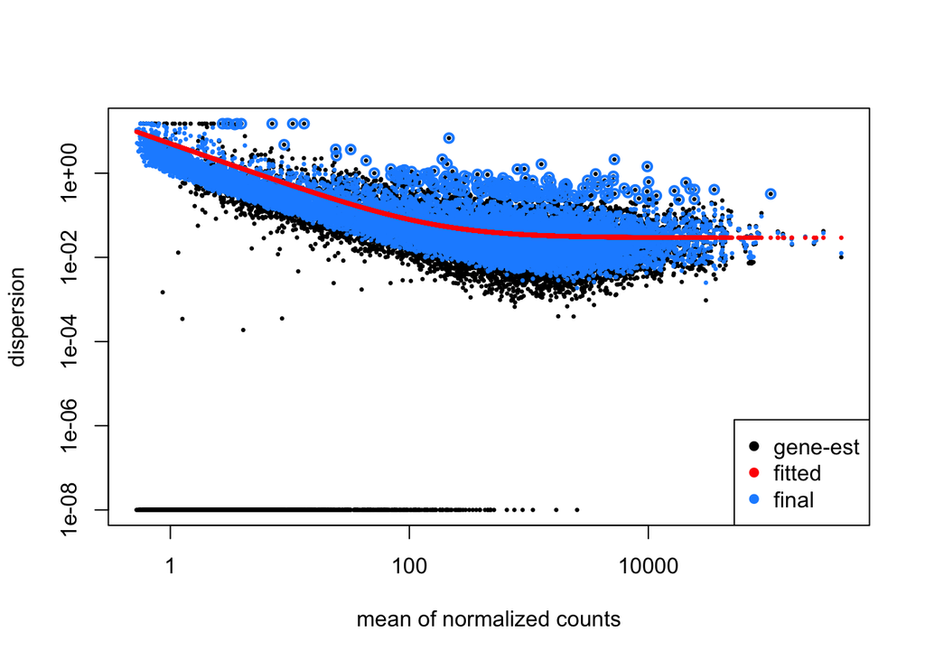

```r
plotDispEsts(dds)
```

What was the normalization scaling that was applied?

```
##  MekDD_1_1 Aktmyr_1_2 ARPE19_1_3 RasV12_1_4  T53D4_1_5  MekDD_3_1 Aktmyr_3_2
##  1.0397904  1.1788374  1.0949659  0.8801052  0.9450042  0.7585786  0.7618003
## ARPE19_3_3 RasV12_3_4  T53D4_3_5 RasV12_2_4  T53D4_2_5  MekDD_2_1 Aktmyr_2_2
##  0.7665800  0.7124837  0.6708042  1.3581927  1.4926175  1.2752768  1.4494699
## ARPE19_2_3
##  1.2498574
```

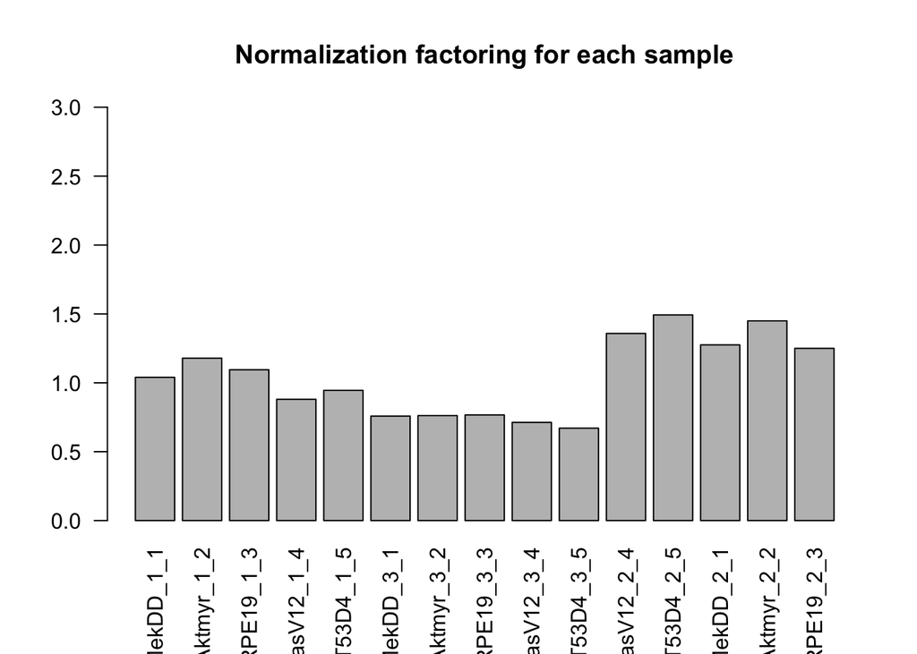

## Step 5: Append Ensemble identifiers to our dataset

First, import the gene names, either from EnsemblDB or from an input file:

```r
# Second time on...import the gene_names from the input folder
gene_names <-read.table(file = "../01_input/210116_ensembleLookuptable.txt", header = TRUE)
```

Write a script to append the gene names to the identifiers in a data.frame:

## Step 6: Export data tables.

Some data tables to export and include in the study as supplemental data tables.

```r
###### RAW COUNTS ##########

# create raw counts tables for supplemental figures
raw_counts <- counts(dds, normalized = FALSE)
merged_raw_counts <- add_external_name(raw_counts)

###### NORMALIZED COUNTS ##########

# create normalized counts tables for supplemental figures
norm_counts <- counts(dds, normalized = TRUE)
merged_norm_counts <- add_external_name(norm_counts)

###### R-STABILIZED LOG COUNTS ##########
rdl_all <- as.data.frame(assay(rlog(dds, blind=FALSE)))
merged_rdl <- add_external_name(rdl_all)

####### save raw counts file for supplemental datatable ######
filename = paste("../03_output/", today, "_raw_counts.txt", sep = "")
write.table(merged_raw_counts, file = filename, sep = "\t", quote = FALSE, row.names = FALSE)

####### save normalized raw counts file for supplemental datatable ######
filename = paste("../03_output/", today, "_norm_counts.txt", sep = "")
write.table(merged_norm_counts, file = filename, sep = "\t", quote = FALSE, row.names = FALSE)

####### save normalized raw counts file for supplemental datatable ######
filename = paste("../03_output/", today, "_RStabilized_log_counts.txt", sep = "")
write.table(merged_rdl, file = filename, sep = "\t", quote = FALSE, row.names = FALSE)
```

## Step 7: Plot a distance matrix

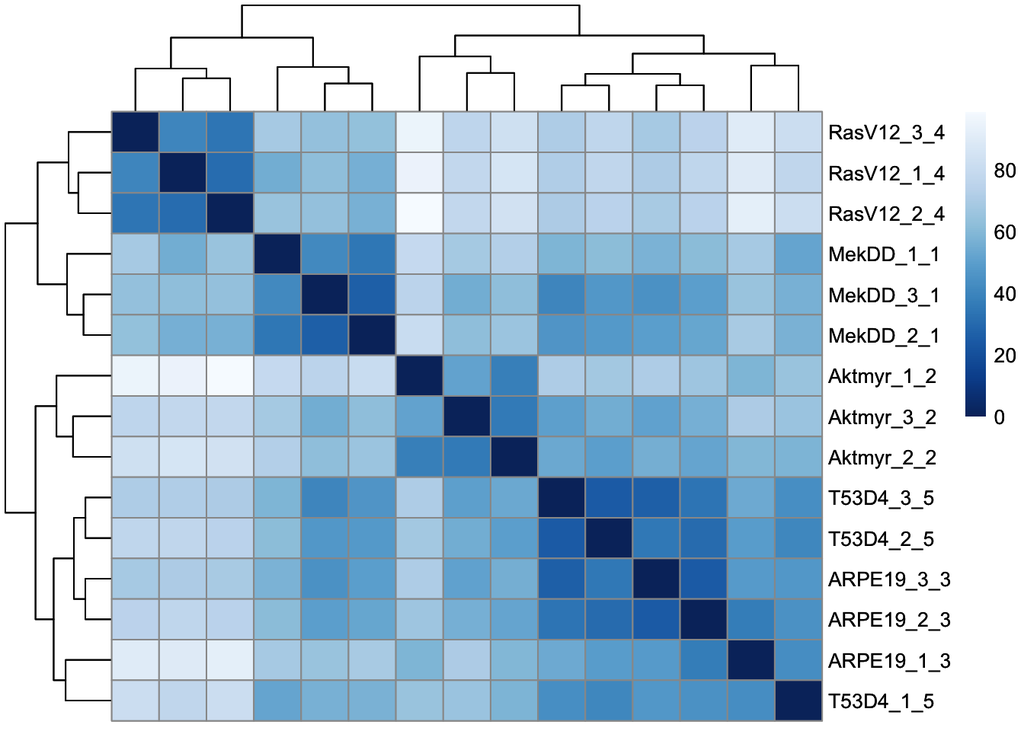

## Step 8: Generate a PCA plot:

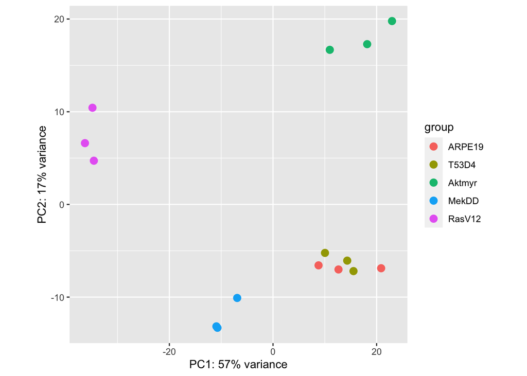

## Step 9: Plot some key, individual genes

Write the function plot_ensembl and gather genes:

- “CCND1”, “CDK4”, “TERT”, “TP53”, “AKT1”, “MAP2K1”, “HRAS”

```
## [1] "CCND1_transgene"        "CDK4r24c_transgene"     "HRASV12_transgene"
## [4] "MEKDD_transgene"        "murine_p53DD_transgene" "MYR_FLAG_AKT_transgene"
## [7] "TERT_transgene"
```

```
## [1] "AKT1"   "CCND1"  "CDK4"   "HRAS"   "MAP2K1" "TERT"   "TP53"
```

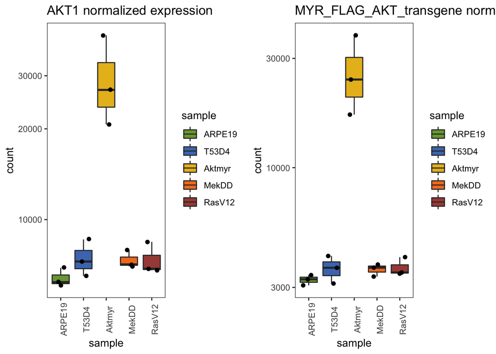

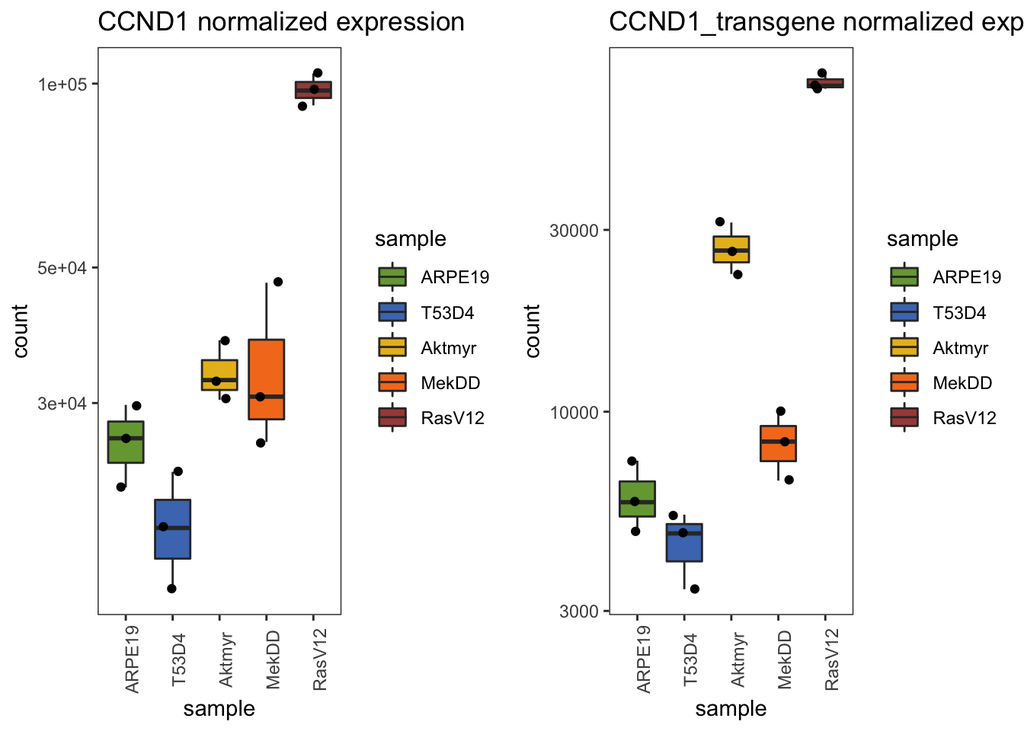

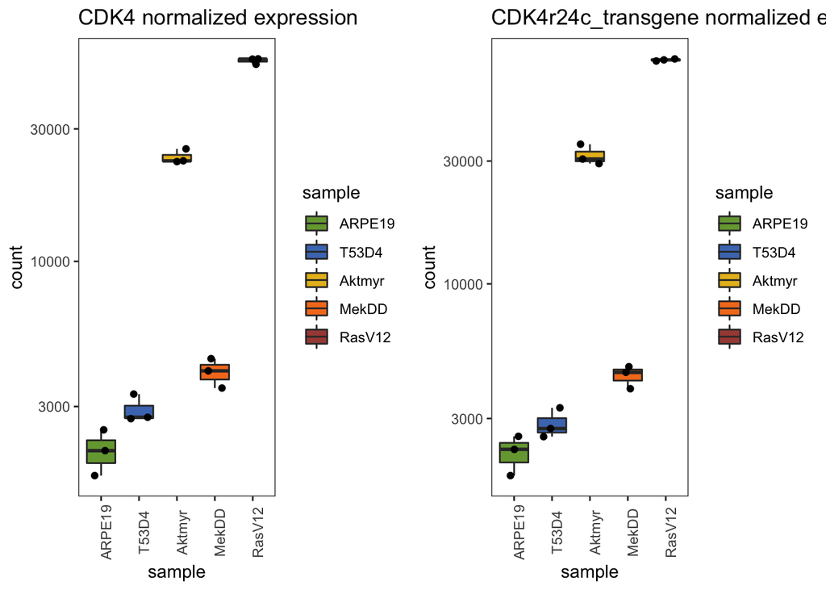

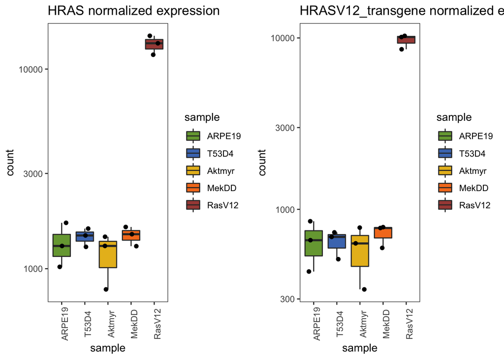

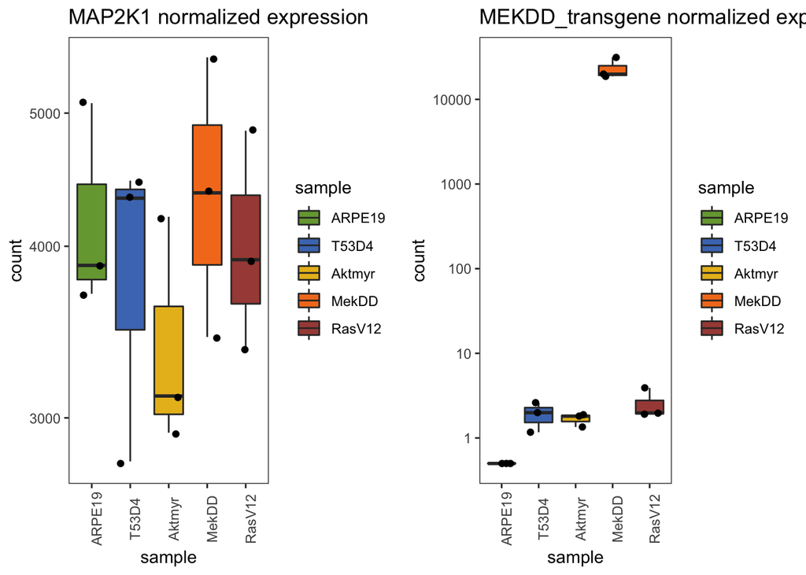

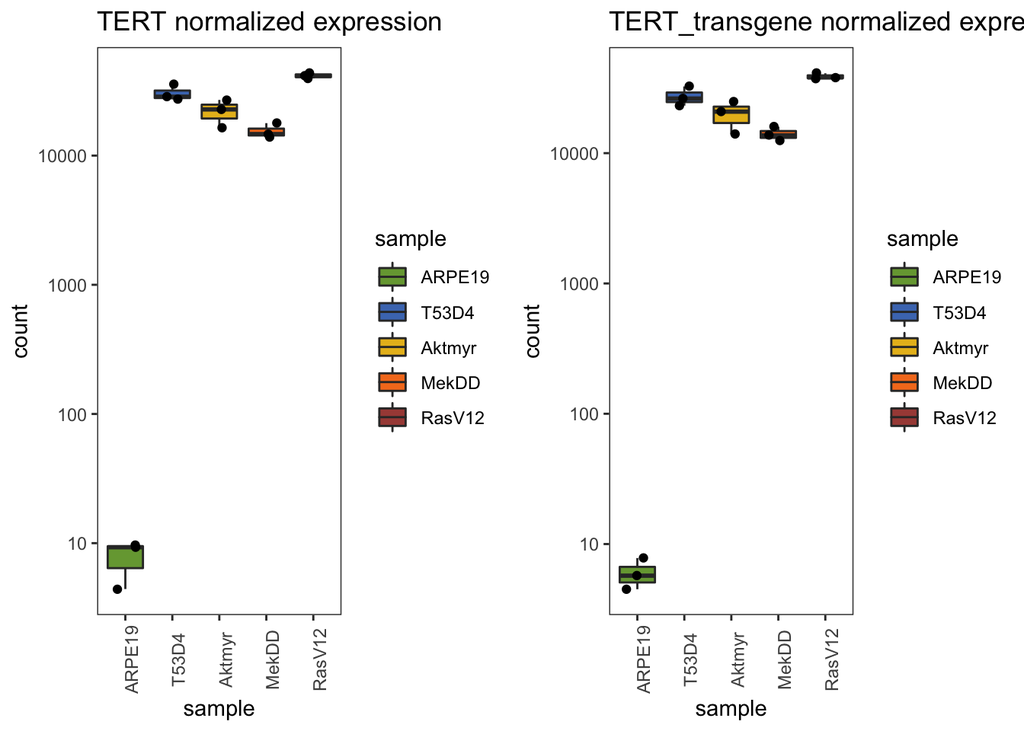

[figure not shown]

## Step 10: Identify pairwise differentially expressed genes

Write function calc_pairwise_results to calculate pairwise results tables

Calculate all pairwise comparisons

```r
# Write key functions to calculate Threshold values


calc_pairwise_results <- function(cond1, cond2, lfc){
  res <- results(dds, contrast=c("sample", cond1, cond2),
                 alpha = 0.1, lfcThreshold = lfc, cooksCutoff = FALSE)
  res <- res[order(res$padj, na.last = TRUE),]
  return(res)
}

# Perform pairwise comparisons ARPE19
# lfc = 0.2; default padj = 0.1
res_ARPE19_vs_T53D4 <- calc_pairwise_results("T53D4","ARPE19", 0.25)
res_ARPE19_vs_Aktmyr <- calc_pairwise_results("Aktmyr", "ARPE19", 0.25)
res_ARPE19_vs_MekDD <- calc_pairwise_results("MekDD", "ARPE19", 0.25)
res_ARPE19_vs_RasV12 <- calc_pairwise_results("RasV12", "ARPE19", 0.25)

#Perform pairwise comparisons T53D4
res_T53D4_vs_Aktmyr <- calc_pairwise_results("Aktmyr", "T53D4", 0.25)
res_T53D4_vs_MekDD <- calc_pairwise_results("MekDD", "T53D4", 0.25)
res_T53D4_vs_RasV12 <- calc_pairwise_results("RasV12", "T53D4", 0.25)

#Perform pairwise comparisons Aktmyr
res_Aktmyr_vs_MekDD <- calc_pairwise_results("MekDD", "Aktmyr", 0.25)
res_Aktmyr_vs_RasV12 <- calc_pairwise_results("RasV12", "Aktmyr", 0.25)

#Perform pairwise comparisons MekDD
resMekDD_vs_RasV12 <- calc_pairwise_results("RasV12", "MekDD", 0.25)
```

Report the summaries of the res-plots:

```r
#remove transgenes
remove_transgenes_from_results <- function(results_object){
  new_results <- results_object[grep("transgene", rownames(results_object), invert = TRUE),]
  return(new_results)
}


# Remove Transgenes
res_ARPE19_vs_T53D4 <- remove_transgenes_from_results(res_ARPE19_vs_T53D4)
res_ARPE19_vs_RasV12 <- remove_transgenes_from_results(res_ARPE19_vs_RasV12)
res_ARPE19_vs_MekDD <- remove_transgenes_from_results(res_ARPE19_vs_MekDD)
res_ARPE19_vs_Aktmyr <- remove_transgenes_from_results(res_ARPE19_vs_Aktmyr)

# Report summaries
summary(res_ARPE19_vs_T53D4)
```

```
##
## out of 15510 with nonzero total read count
## adjusted p-value < 0.1
## LFC > 0.25 (up)    : 12, 0.077%
## LFC < -0.25 (down) : 25, 0.16%
## outliers [1]       : 0, 0%
## low counts [2]     : 602, 3.9%
## (mean count < 1)
## [1] see 'cooksCutoff' argument of ?results
## [2] see 'independentFiltering' argument of ?results
```

```r
summary(res_ARPE19_vs_RasV12)
```

```
##
## out of 15510 with nonzero total read count
## adjusted p-value < 0.1
## LFC > 0.25 (up)    : 1073, 6.9%
## LFC < -0.25 (down) : 1625, 10%
## outliers [1]       : 0, 0%
## low counts [2]     : 301, 1.9%
## (mean count < 1)
## [1] see 'cooksCutoff' argument of ?results
## [2] see 'independentFiltering' argument of ?results
```

```r
summary(res_ARPE19_vs_MekDD)
```

```
##
## out of 15510 with nonzero total read count
## adjusted p-value < 0.1
## LFC > 0.25 (up)    : 300, 1.9%
## LFC < -0.25 (down) : 588, 3.8%
## outliers [1]       : 0, 0%
## low counts [2]     : 0, 0%
## (mean count < 1)
## [1] see 'cooksCutoff' argument of ?results
## [2] see 'independentFiltering' argument of ?results
```

```r
summary(res_ARPE19_vs_Aktmyr)
```

```
##
## out of 15510 with nonzero total read count
## adjusted p-value < 0.1
## LFC > 0.25 (up)    : 624, 4%
## LFC < -0.25 (down) : 687, 4.4%
## outliers [1]       : 0, 0%
## low counts [2]     : 602, 3.9%
## (mean count < 1)
## [1] see 'cooksCutoff' argument of ?results
## [2] see 'independentFiltering' argument of ?results
```

## Step 11: Plot the MA-Plots

MA plots of pairwise comparisons

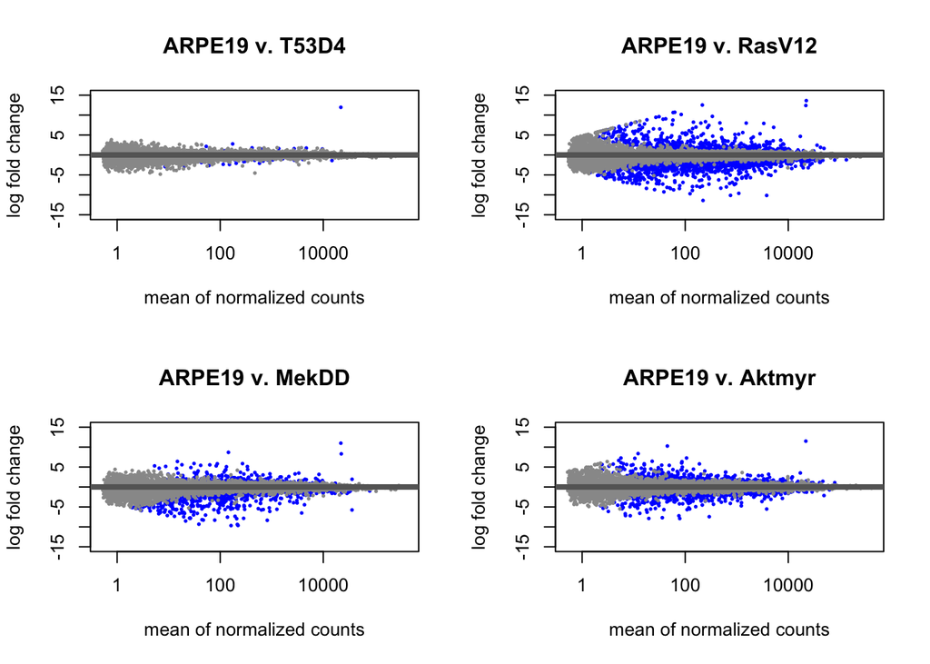

Save MA plots to .pdf’s:

```r
# Printout MA-Plots
filename = paste("../03_output/", today, "_MAplots.pdf", sep = "")
pdf(file = filename, height = 6, width = 6)
  par(mfrow=c(2,2))
  plotMA(res_ARPE19_vs_T53D4, main="ARPE19 v. T53D4", ylim=c(-15,15))
  plotMA(res_ARPE19_vs_RasV12, main="ARPE19 v. RasV12", ylim=c(-15,15))
  plotMA(res_ARPE19_vs_MekDD, main="ARPE19 v. MekDD", ylim=c(-15,15))
  plotMA(res_ARPE19_vs_Aktmyr, main="ARPE19 v. Aktmyr", ylim=c(-15,15))
  dev.off()
```

## Step 12: Generate and export gene lists

```r
# find the up_in_X and down_in_X genesets:
# lfc = 0.2; alpha = 0.1

# Up in
Up_in_T53D4 <- subset(res_ARPE19_vs_T53D4, padj < 0.1 & log2FoldChange > 0.25)
Up_in_Akt <- subset(res_ARPE19_vs_Aktmyr, padj < 0.1 & log2FoldChange > 0.25)
Up_in_Mek <- subset(res_ARPE19_vs_MekDD, padj < 0.1 & log2FoldChange > 0.25)
Up_in_Ras <- subset(res_ARPE19_vs_RasV12, padj < 0.1 & log2FoldChange > 0.25)

# Down in
Down_in_T53D4 <- subset(res_ARPE19_vs_T53D4, padj < 0.1 & log2FoldChange < -0.25)
Down_in_Akt <- subset(res_ARPE19_vs_Aktmyr, padj < 0.1 & log2FoldChange < -0.25)
Down_in_Mek <- subset(res_ARPE19_vs_MekDD, padj < 0.1 & log2FoldChange < -0.25)
Down_in_Ras <- subset(res_ARPE19_vs_RasV12, padj < 0.1 & log2FoldChange < -0.25)

# Add external names
merged_up_in_T53D4 <- add_external_name(Up_in_T53D4)
merged_up_in_Akt <- add_external_name(Up_in_Akt)
merged_up_in_Mek <- add_external_name(Up_in_Mek)
merged_up_in_Ras <- add_external_name(Up_in_Ras)

merged_down_in_T53D4 <- add_external_name(Down_in_T53D4)
merged_down_in_Akt <- add_external_name(Down_in_Akt)
merged_down_in_Mek <- add_external_name(Down_in_Mek)
merged_down_in_Ras <- add_external_name(Down_in_Ras)

# Write files:
filename1 = paste("../03_output/", today, "_1_upInRas_ENSBL.txt", sep = "")
write(file = filename1, merged_up_in_Ras$EnsembleGeneName, sep = "\n")

filename2 = paste("../03_output/", today, "_2_upInMek_ENSBL.txt", sep = "")
write(file = filename2, merged_up_in_Mek$EnsembleGeneName, sep = "\n")

filename3 = paste("../03_output/", today, "_3_upInAkt_ENSBL.txt", sep = "")
write(file = filename3, merged_up_in_Akt$EnsembleGeneName, sep = "\n")

filename4 = paste("../03_output/", today, "_4_downInRas_ENSBL.txt", sep = "")
write(file = filename4, merged_down_in_Ras$EnsembleGeneName, sep = "\n")

filename5 = paste("../03_output/", today, "_5_downInMek_ENSBL.txt", sep = "")
write(file = filename5, merged_down_in_Mek$EnsembleGeneName, sep = "\n")

filename6 = paste("../03_output/", today, "_6_downInAkt_ENSBL.txt", sep = "")
write(file = filename6, merged_down_in_Akt$EnsembleGeneName, sep = "\n")
```

## Step 13: Generate and export all-changing gene lists

Determine the union set of genes that are changing in all pair-wise conditions with a maximum adjusted p-value of 0.1 and a minimum fold-change of 0.25.

How many genes are in the union set of changing genes?

```
## [1] 5463
```

How many genes are in the complete dataset as a whole?

```
## [1] 15501
```

Save the ensemble and external gene names of the full dataset and the changing set:

```r
filename = paste("../03_output/", today, "_unionSetOfChangingGenes_0.1_0.25.txt", sep = "")
write.table(Union_set_of_all_changing_genes_0.1_0.25, file = filename, sep = "\t", quote = FALSE, row.names = FALSE)

filename = paste("../03_output/", today, "_unionAllGenes_.txt", sep = "")
write.table(Set_of_all_genes, file = filename, sep = "\t", quote = FALSE, row.names = FALSE)
```

## Step 14: Export the results tables and the DESeq object as files

```r
# Write to .txt files
filename = paste("../03_output/", today, "_results_ARPE19Table_vsT53D4.txt", sep = "")
write.table(df_res_ARPE19_vs_T53D4, file = filename, sep = "\t", quote = FALSE, row.names = FALSE)

filename = paste("../03_output/", today, "_resultsTable_ARPE19_vs_Aktmyr.txt", sep = "")
write.table(df_res_ARPE19_vs_Aktmyr, file = filename, sep = "\t", quote = FALSE, row.names = FALSE)

filename = paste("../03_output/", today, "_resultsTable_ARPE19_vs_MekDD.txt", sep = "")
write.table(df_res_ARPE19_vs_MekDD, file = filename, sep = "\t", quote = FALSE, row.names = FALSE)

filename = paste("../03_output/", today, "_resultsTable_ARPE19_vs_RasV12.txt", sep = "")
write.table(df_res_ARPE19_vs_RasV12, file = filename, sep = "\t", quote = FALSE, row.names = FALSE)

filename_dds <- paste("../03_output/", today, "_dds_object.rds", sep = "")
saveRDS(dds, file = filename_dds)
```

```r
citation()
```

```
##
##
##   R Core Team (2020). R: A language and environment for statistical
##   computing. R Foundation for Statistical Computing, Vienna, Austria.
##   URL https://www.R-project.org/.
##
## A BibTeX entry for LaTeX users is
##
##   @Manual{,
##     title = {R: A Language and Environment for Statistical Computing},
##     author = {{R Core Team}},
##     organization = {R Foundation for Statistical Computing},
##     address = {Vienna, Austria},
##     year = {2020},
##     url = {https://www.R-project.org/},
##   }
##
## We have invested a lot of time and effort in creating R, please cite it
## when using it for data analysis. See also 'citation("pkgname")' for
## citing R packages.
```